# Predicting Retention

March 30, 2020

## Overview

In higher education, being able to predict retention is important for multiple reasons including:

- Provide support services for students “at-risk”
- Used by some college rankings (e.g. [US News](https://www.usnews.com/best-colleges))

Many colleges use admissions tests (e.g. ACT, SAT) to determine admission to the college. Our guiding research question is:

**Does addmission tests predict college retention?**

Retention is defined as:

> A measure of the rate at which students persist in their educational program at an institution, expressed as a percentage. For four-year institutions, this is the percentage of first-time bachelors (or equivalent) degree-seeking undergraduates from the previous fall who are again enrolled in the current fall. For all other institutions this is the percentage of first-time degree/certificate-seeking students from the previous fall who either re-enrolled or successfully completed their program by the current fall. ([IPEDS, 2019](https://surveys.nces.ed.gov/ipeds/VisInstructions.aspx?survey=6&id=30074&show=all))

## Data Source

The [Integrated Postsecondary Education Data System (IPEDS)](https://nces.ed.gov/ipeds/) provides information about all higher education institutions that provide Federal Finacial Aid to students.

| SurveyID | Survey | Title |
| --- | --- | --- |
| HD | Institutional Characteristics | Directory information |
| IC | Institutional Characteristics | Educational offerings, organization, admissions, services and athletic associations |
| IC_AY | Institutional Characteristics | Student charges for academic year programs |
| IC_PY | Institutional Characteristics | Student charges by program (vocational programs) |
| FLAGS | Institutional Characteristics | Response status for all survey components |
| EFEST | Enrollments | Estimated enrollment |
| EFA | Enrollments | Race/ethnicity, gender, attendance status, and level of students: Fall |
| EFANR | Enrollments | Race/ethnicity, gender, attendance status, and level of students: Fall prior to 2000 |
| EFB | Enrollments | Age category, gender, attendance status, and level of student: Fall |
| EFC | Enrollments | Residence and migration of first-time freshman: Fall |

[output cut: 56 more lines]

## Data Preparation

The [`ipeds`](https://github.com/jbryer/ipeds) R package provides an interface to download IPEDS data directly into R.

```r
directory <- getIPEDSSurvey('HD', 2011)
admissions <- getIPEDSSurvey("IC", 2011)
retention <- getIPEDSSurvey("EFD", 2011)
```

We will subset the columns we are interested in and rename them.

```r
directory <- directory[,c('unitid', 'instnm', 'sector', 'control')]
admissions <- admissions[,c('unitid', 'admcon1', 'admcon2', 'admcon7', 'applcnm',
                           'applcnw', 'applcn', 'admssnm', 'admssnw', 'admssn',
                           'enrlftm', 'enrlftw', 'enrlptm', 'enrlptw', 'enrlt',
                           'satnum', 'satpct', 'actnum', 'actpct', 'satvr25',
                           'satvr75', 'satmt25', 'satmt75', 'satwr25', 'satwr75',
                           'actcm25', 'actcm75', 'acten25', 'acten75', 'actmt25',
                           'actmt75', 'actwr25', 'actwr75')]
retention <- retention[,c('unitid', 'ret_pcf', 'ret_pcp')]
```

## Data Preparation: Rename Columns

```r
names(admissions) <- c("unitid", "UseHSGPA", "UseHSRank", "UseAdmissionTestScores",
                      "ApplicantsMen", "ApplicantsWomen", "ApplicantsTotal",
                      "AdmissionsMen", "AdmissionsWomen", "AdmissionsTotal",
                      "EnrolledFullTimeMen", "EnrolledFullTimeWomen",
                      "EnrolledPartTimeMen", "EnrolledPartTimeWomen",
                      "EnrolledTotal", "NumSATScores", "PercentSATScores",
                      "NumACTScores", "PercentACTScores", "SATReading25",
                      "SATReading75", "SATMath25", "SATMath75", "SATWriting25",
                      "SATWriting75", "ACTComposite25", "ACTComposite75",
                      "ACTEnglish25", "ACTEnglish75", "ACTMath25", "ACTMath75",
                      "ACTWriting25", "ACTWriting75")
names(retention) = c("unitid", "FullTimeRetentionRate", "PartTimeRetentionRate")
```

## Data Preparation: Recoding

```r
admissionsLabels = c("Required", "Recommended", "Neither requiered nor recommended",
                     "Do not know", "Not reported", "Not applicable")
admissions$UseHSGPA = factor(admissions$UseHSGPA, levels=c(1,2,3,4,-1,-2),
                            labels=admissionsLabels)
admissions$UseHSRank = factor(admissions$UseHSRank, levels=c(1,2,3,4,-1,-2),
                            labels=admissionsLabels)
admissions$UseAdmissionTestScores = factor(admissions$UseAdmissionTestScores, levels=c(1,2,3,4,-1,-2),
                            labels=admissionsLabels)
```

## Data Preparation: Merging

```r
ret <- merge(directory, admissions, by="unitid")
ret <- merge(ret, retention, by="unitid")
#Use schools that require or recommend admission tests
ret2 <- ret[ret$UseAdmissionTestScores %in%
            c('Required', 'Recommended', 'Neither requiered nor recommended'),]
#Remove schools with low retention rates. Are these errors in the data?
ret2 <- ret2[-which(ret2$FullTimeRetentionRate < 20),]
```

```r
head(ret2, n = 3)
```

```
##   unitid                              instnm sector control UseHSGPA
## 1 100654            Alabama A & M University      1       1 Required
## 2 100663 University of Alabama at Birmingham      1       1 Required
## 4 100706 University of Alabama at Huntsville      1       1 Required
##                           UseHSRank UseAdmissionTestScores ApplicantsMen
## 1                       Recommended               Required          2847
## 2 Neither requiered nor recommended               Required          2307
## 4                       Recommended               Required          1100
##   ApplicantsWomen ApplicantsTotal AdmissionsMen AdmissionsWomen AdmissionsTotal
## 1            4309            7156          1442            2143            3585
## 2            3268            5575          1692            2335            4027
## 4             852            1952           719             524            1243
##   EnrolledFullTimeMen EnrolledFullTimeWomen EnrolledPartTimeMen
## 1                 421                   435                   5
## 2                 687                   891                  15
```

[output cut: 21 more lines]

## Data Preparation: SAT and ACT Scores

IPEDS only provides the 25th and 75th percentile in SAT and ACT scores. We will use the mean of these two values as a proxy for the mean.

```r
ret2$SATMath75 <- as.numeric(ret2$SATMath75)
ret2$SATMath25 <- as.numeric(ret2$SATMath25)
ret2$SATMath <- (ret2$SATMath75 + ret2$SATMath25) / 2
ret2$SATWriting75 <- as.numeric(ret2$SATWriting75)
ret2$SATWriting25 <- as.numeric(ret2$SATWriting25)
ret2$SATWriting <- (ret2$SATWriting75 + ret2$SATWriting25) / 2
ret2$SATTotal <- ret2$SATMath + ret2$SATWriting
ret2$NumSATScores <- as.integer(ret2$NumSATScores)
```

## Data Preparation: Selectivity

Calculate the the selectivity of the institution by calculating the acceptance rate (i.e. # admissions / # applicants).

```r
ret2$Selectivity <- as.numeric(ret2$AdmissionsTotal) /
                as.numeric(ret2$ApplicantsTotal)
ret2$UseAdmissionTestScores <- as.factor(as.character(ret2$UseAdmissionTestScores))
```

## Descriptive Statistics: FullTimeRetentionRate

```r
psych::describe(ret2$FullTimeRetentionRate)
```

```
##    vars    n  mean    sd median trimmed   mad min max range  skew kurtosis   se
## X1    1 2234 73.68 14.49     75    74.4 13.34  20 100    80 -0.55     0.48 0.31
```

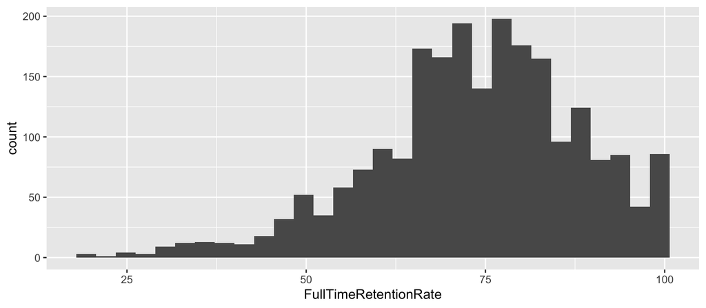

```r
ggplot(ret2, aes(x = FullTimeRetentionRate)) + geom_histogram()
```

## Descriptive Statistics: SATMath

```r
psych::describe(ret2$SATMath)
```

```
##    vars    n   mean    sd median trimmed  mad min max range skew kurtosis   se
## X1    1 1294 532.07 70.92    520   526.4 59.3 350 780   430 0.77     0.69 1.97
```

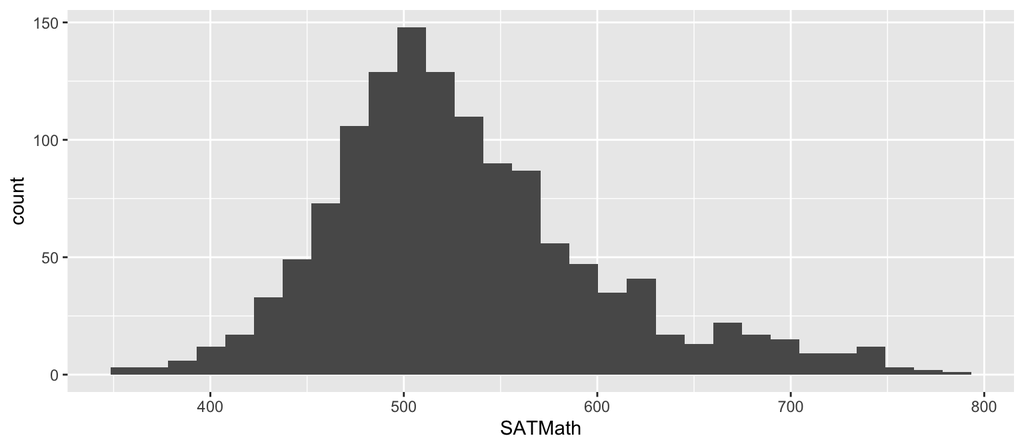

```r
ggplot(ret2, aes(x = SATMath)) + geom_histogram()
```

## Descriptive Statistics: SATWriting

```r
psych::describe(ret2$SATWriting)
```

```
##    vars   n   mean   sd median trimmed   mad min max range skew kurtosis   se
## X1    1 749 521.82 78.8    510  515.48 66.72 325 755   430 0.69     0.26 2.88
```

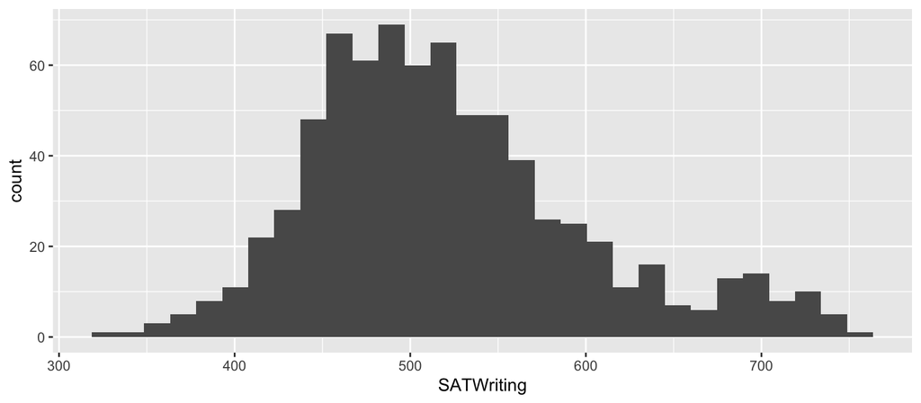

```r
ggplot(ret2, aes(x = SATWriting)) + geom_histogram()
```

## SAT Scores vs. Full-Time Retention

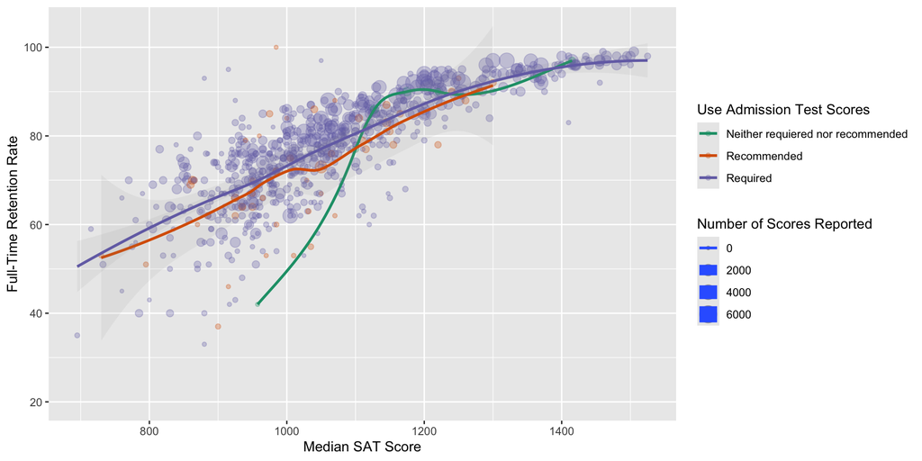

## Regression Analysis

## Regression Results

```r
lm.out <- lm(FullTimeRetentionRate ~ SATWriting + SATMath +
             Selectivity + UseAdmissionTestScores,
             data=ret2,
             weights=ret2$NumSATScores)
```

```
##                                    Estimate Std. Error t value  Pr(>|t|)
## (Intercept)                       10.978338   3.810083  2.8814  0.004073 **
## SATWriting                         0.040317   0.010305  3.9125 9.974e-05 ***
## SATMath                            0.084695   0.009935  8.5249 < 2.2e-16 ***
## Selectivity                        4.116193   1.403863  2.9320  0.003471 **
## UseAdmissionTestScoresRecommended -4.253294   2.948248 -1.4427  0.149540
## UseAdmissionTestScoresRequired    -1.003809   2.715252 -0.3697  0.711717
## ---
## Signif. codes:  0 '***' 0.001 '**' 0.01 '*' 0.05 '.' 0.1 ' ' 1
```

Adjusted \(R^2\) = 0.75

## Conclusion (Regression)

SAT scores are a significant predictor of full-time retention rates for higher education institutions in the United States.

SAT scores and selectivity account for approximately 75% of the variance of full-time retention.

## Null Hypothesis Test

## Descriptive Statistics: UseAdmissionTestScores

```r
table(ret2$UseAdmissionTestScores)
```

```
##
## Neither requiered nor recommended                       Recommended                          Required
##                               716                               372                              1312
```

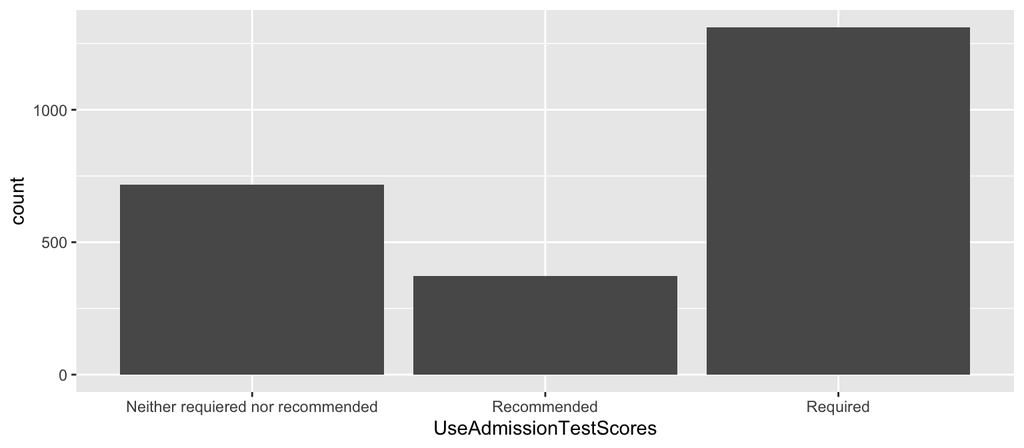

```r
ggplot(ret2, aes(x = UseAdmissionTestScores)) + geom_bar()
```

## Null Hypothesis Test

\(H_0\): There is no difference in retention rate between institutions that require SAT scores and those that do not.

\(H_A\): There is a difference in the retention rate between institutions that require SAT scores and those that do not.

We will exclude the “Recommended” group so that we have two groups.

```r
ret3 <- ret2[ret2$UseAdmissionTestScores != 'Recommended',]
```

## Student’s t-test

```r
t.results <- t.test(FullTimeRetentionRate ~ UseAdmissionTestScores, data = ret3)
print(t.results)
```

```
##
##  Welch Two Sample t-test
##
## data:  FullTimeRetentionRate by UseAdmissionTestScores
## t = -3.3141, df = 824.25, p-value = 0.0009596
## alternative hypothesis: true difference in means is not equal to 0
## 95 percent confidence interval:
##  -4.074965 -1.043451
## sample estimates:
## mean in group Neither requiered nor recommended                          mean in group Required
##                                        72.62963                                        75.18884
```

## Conclusion (Null Hypothesis test)

There is sufficient evidence to reject the null hypothesis (*p* < 0.01). There is a difference in retention rates between schools that require SAT scores (75.19) and those that do not (72.63).

We are 95% confident the true difference is between -4.07 and -1.04.

## ANOVA

## Null Hypothesis for ANOVA

\(H_0\): The mean retention rate is the same whether an institution requires, recommends, and neither require nor recommend SAT scores.

\(H_A\): There is a difference in the mean retention scores between the three groups.

## ANOVA

```r
anova.results <- aov(FullTimeRetentionRate ~ UseAdmissionTestScores, data = ret2)
summary(anova.results)
```

```
##                          Df Sum Sq Mean Sq F value   Pr(>F)
## UseAdmissionTestScores    2   8817    4409   21.38 6.34e-10 ***
## Residuals              2231 460005     206
## ---
## Signif. codes:  0 '***' 0.001 '**' 0.01 '*' 0.05 '.' 0.1 ' ' 1
## 166 observations deleted due to missingness
```

### Conclusion (ANOVA)

There is sufficient evidence to reject the null hypothesis (p < 0.01), there is a difference in the retention rate depending on the requirement of SAT scores.